# Data exploration for ‘survey’ dataset

Henry Baker

2023-12-09

## Loading & initial look at data

```r
setwd("/Users/henrybaker/Library/Mobile Documents/com~apple~CloudDocs/Documents/GitHub/IDS'23/hackathon-project-individual-henrycgbaker")

survey_data <- readRDS("survey/meof_usa_survey_df.RDS")

#str(survey_data)
#summary(survey_data)

survey_data_variables <- names(survey_data)
```

```r
#tracking
tracking_data <- readRDS("tracking/meof_usa_web_df.RDS")
#str(tracking_data)
#summary(tracking_data)

tracking_data_variables <- names(tracking_data)

# time zones
time_zones <- readRDS("tracking/time_zones.RDS")
#str(time_zones)
#summary(time_zones)
```

## Attempted to do a data mining attempt here (failed)

this was meant to look at the covariance between all columns to see if any initial patterns & correlations emerged, but the data isn’t properly numeric and most of it drops out.

```r
# doesn't work - too many omitted columns:

selected_data <- select(survey_data, -c(1:7))
# Identify numeric and convertible columns
numeric_columns <- sapply(selected_data, function(x) is.numeric(x) || is.factor(x))

# Convert  to numeric
survey_numeric <- data.frame(lapply(selected_data[, numeric_columns, drop = FALSE], function(x) {
  if (is.factor(x)) {
    as.numeric(as.character(x))
  } else {
    as.numeric(x)
  }
}))

#  compute covariance
vc_survey <- cov(survey_numeric)
```

## basic transfomrations to make data more useable moving forwards

Continue to add to this as make basic changes - group them altogether here so can keep track

```r
#create new party variable for ease of use
survey_data$party <- ifelse(survey_data$pid3 == 1, "democrat", "republican")

# create a  republican subset
repub_subset <- survey_data |>
  filter(party == "republican") |>
  group_by(personid)

n_repub <- nrow(repub_subset)

# create a democratic subset
demo_subset <- survey_data |>
  filter(party == "democrat") |>
  group_by(personid)

n_demo <- nrow(demo_subset)
# NB signifanctly less democrats !
```

## Basic demographic distributions

### Republicans

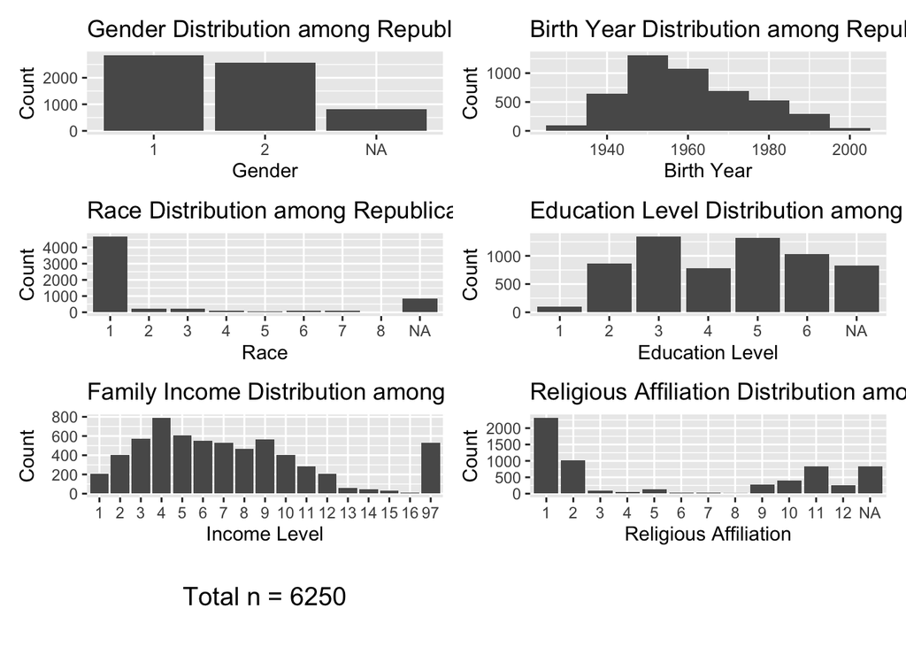

```r
par(mfrow = c(3, 3))

# Gender
gender_plot <- ggplot(repub_subset, aes(x = factor(gender))) +
  geom_bar() +
  labs(title = "Gender Distribution among Republican Respondents", x = "Gender", y = "Count")

# Birth Year
birthyr_plot <- ggplot(repub_subset, aes(x = birthyr)) +
  geom_histogram(binwidth = 10) +
  labs(title = "Birth Year Distribution among Republican Respondents", x = "Birth Year", y = "Count")

# Race
race_plot <- ggplot(repub_subset, aes(x = factor(race))) +
  geom_bar() +
  labs(title = "Race Distribution among Republican Respondents", x = "Race", y = "Count")

# Education
educ_plot <- ggplot(repub_subset, aes(x = factor(educ))) +
  geom_bar() +
  labs(title = "Education Level Distribution among Republican Respondents", x = "Education Level", y = "Count")

# Family Income
faminc_plot <- ggplot(repub_subset, aes(x = factor(faminc_new))) +
  geom_bar() +
  labs(title = "Family Income Distribution among Republican Respondents", x = "Income Level", y = "Count")

# Religious Pew
regligpew_plot <- ggplot(repub_subset, aes(x = factor(religpew))) +
  geom_bar() +
  labs(title = "Religious Affiliation Distribution among Republican Respondents", x = "Religious Affiliation", y = "Count")

# Combine the plots in a 3x2 layout
n_label_plot_repub <- ggplot() +
  annotate("text", x = 0, y = 0, label = paste("Total n =", n_repub), size = 5) +
  theme_void()

combined_plot <- gender_plot / birthyr_plot / race_plot / educ_plot / faminc_plot / regligpew_plot / n_label_plot_repub +
                 plot_layout(ncol = 2, nrow = 4)

combined_plot
```

For religious affiliation: 1 = prot 2 = catholic 11 = nothing in particular

### Democrats

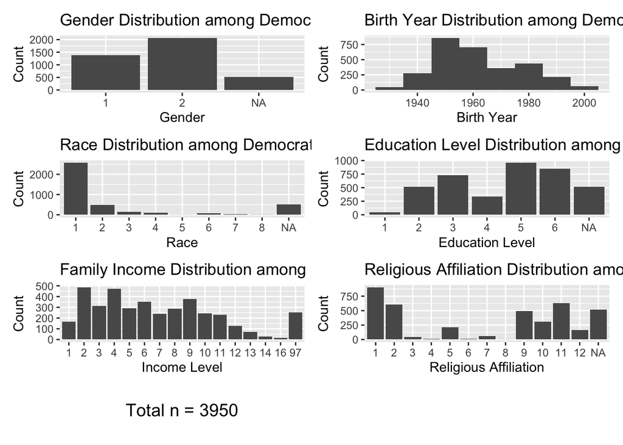

```r
par(mfrow = c(3, 2))

# Gender
gender_plot <- ggplot(demo_subset, aes(x = factor(gender))) +
  geom_bar() +
  labs(title = "Gender Distribution among Democratic Respondents", x = "Gender", y = "Count")

# Birth Year
birthyr_plot <- ggplot(demo_subset, aes(x = birthyr)) +
  geom_histogram(binwidth = 10) +
  labs(title = "Birth Year Distribution among Democratic Respondents", x = "Birth Year", y = "Count")

# Race
race_plot <- ggplot(demo_subset, aes(x = factor(race))) +
  geom_bar() +
  labs(title = "Race Distribution among Democratic Respondents", x = "Race", y = "Count")

# Education
educ_plot <- ggplot(demo_subset, aes(x = factor(educ))) +
  geom_bar() +
  labs(title = "Education Level Distribution among Democratic Respondents", x = "Education Level", y = "Count")

# Family Income
faminc_plot <- ggplot(demo_subset, aes(x = factor(faminc_new))) +
  geom_bar() +
  labs(title = "Family Income Distribution among Democratic Respondents", x = "Income Level", y = "Count")

# Religious Pew
regligpew_plot <- ggplot(demo_subset, aes(x = factor(religpew))) +
  geom_bar() +
  labs(title = "Religious Affiliation Distribution among Republican Respondents", x = "Religious Affiliation", y = "Count")

# Combine the plots in a 3x2 layout
n_label_plot_demo <- ggplot() +
  annotate("text", x = 0, y = 0, label = paste("Total n =", n_demo), size = 5) +
  theme_void()

combined_plot <- gender_plot / birthyr_plot / race_plot / educ_plot / faminc_plot / regligpew_plot / n_label_plot_demo +
                 plot_layout(ncol = 2, nrow = 4)

combined_plot
```

NB: many fewer democrats in the sample

## System trust by party

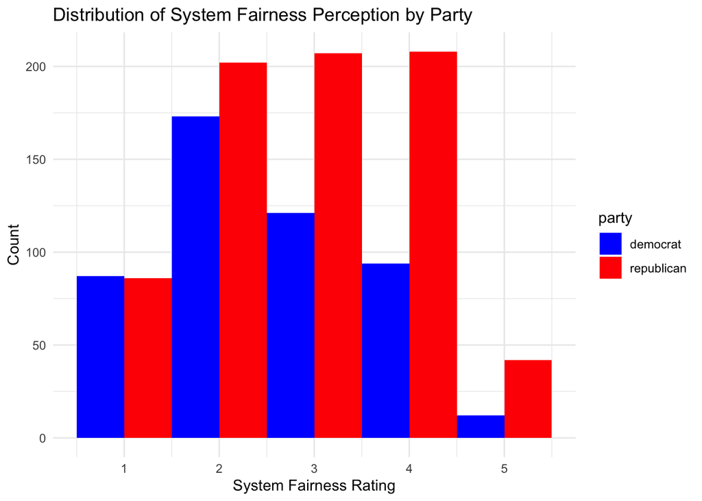

```r
ggplot(survey_data, aes(x = system_fair, fill = party)) +
  geom_histogram(position = "dodge", binwidth = 1) +
  scale_fill_manual(values = c("democrat" = "blue", "republican" = "red")) +
  labs(title = "Distribution of System Fairness Perception by Party",
       x = "System Fairness Rating",
       y = "Count") +
  theme_minimal()
```

1 = strongly disagree 5 = strongly agree

this is interesting - more antisystem sentiment amongst democrats Also high variance - definitely an interesting variable to unpack - what predictors for system_fair in survey data - would be very interesting to see how tracking data maps on to this - changes over time? recorded in all 7 waves: look how system trust changes for specific subsets within parties over time? - does it change with changes in tracking data website visits and news consumption - is it associated with non legacy media consumption? (age interaction term?) - diff in diff model: get baseline of similar units, then see how consumption of certain media in intervention group changes trust in system compared to control units? - do late night users have less trust?

## Platform statistics by party

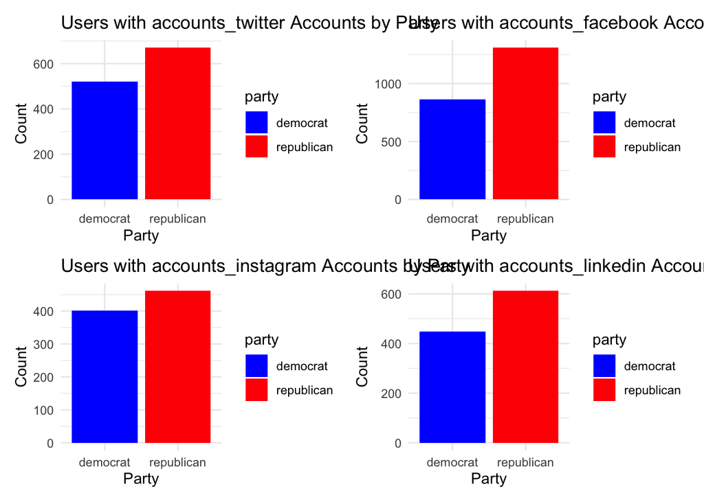

```r
# function to create plot for a social media platform
platform_plot_fn <- function(data, platform, party_col = "party") {
  ggplot(data, aes_string(x = party_col, fill = party_col)) +
    geom_bar(data = subset(data, get(platform) == 1)) +
    labs(title = paste("Users with", platform, "Accounts by Party"),
         x = "Party",
         y = "Count") +
    scale_fill_manual(values = c("democrat" = "blue", "republican" = "red")) +
    theme_minimal()
}

# iterate
twitter_plot <- platform_plot_fn(survey_data, "accounts_twitter")
facebook_plot <- platform_plot_fn(survey_data, "accounts_facebook")
instagram_plot <- platform_plot_fn(survey_data, "accounts_instagram")
linkedin_plot <- platform_plot_fn(survey_data, "accounts_linkedin")

combined_plot <- twitter_plot / facebook_plot / instagram_plot / linkedin_plot +
                 plot_layout(ncol = 2)

combined_plot
```

but this is because there are more republicans need to work out as proportion

```r
# function to calc props for each platform
calculate_proportions <- function(data, platform) {
  data |>
    group_by(party) |>
    summarise(Proportion = mean(get(platform) == 1, na.rm = TRUE), .groups = 'drop')
}

# calc propsfor each platform
twitter_proportions <- calculate_proportions(survey_data, "accounts_twitter")
facebook_proportions <- calculate_proportions(survey_data, "accounts_facebook")
instagram_proportions <- calculate_proportions(survey_data, "accounts_instagram")
linkedin_proportions <- calculate_proportions(survey_data, "accounts_linkedin")

twitter_proportions
```

```
## # A tibble: 2 × 2
##   party      Proportion
##   <chr>           <dbl>
## 1 democrat        0.517
## 2 republican      0.428
```

```r
facebook_proportions
```

```
## # A tibble: 2 × 2
##   party      Proportion
##   <chr>           <dbl>
## 1 democrat        0.858
## 2 republican      0.837
```

```r
instagram_proportions
```

```
## # A tibble: 2 × 2
##   party      Proportion
##   <chr>           <dbl>
## 1 democrat        0.4
## 2 republican      0.294
```

```r
linkedin_proportions
```

```
## # A tibble: 2 × 2
##   party      Proportion
##   <chr>           <dbl>
## 1 democrat        0.447
## 2 republican      0.391
```

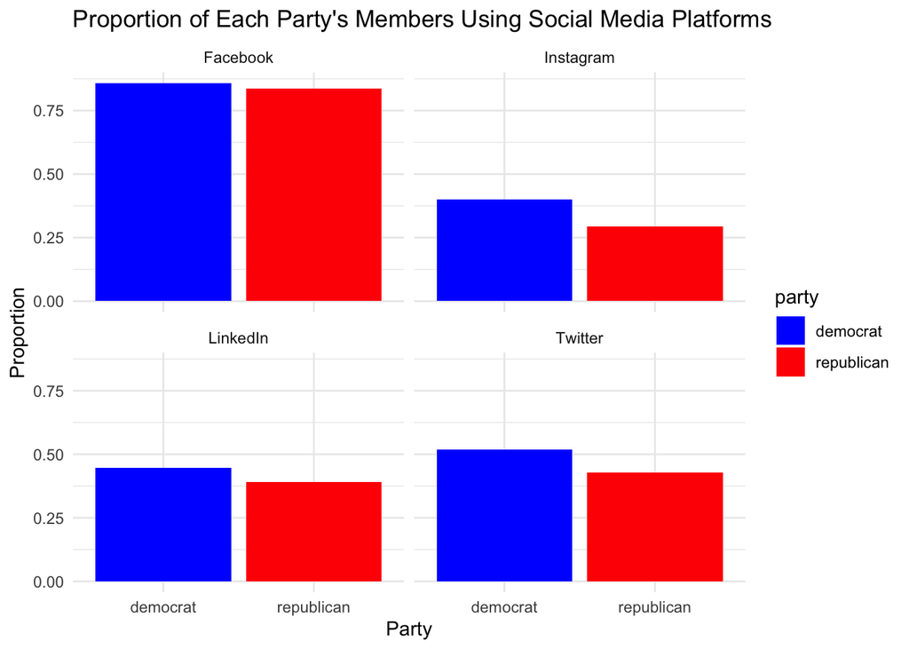

```r
# into one data frame
combined_proportions <- bind_rows(
  mutate(twitter_proportions, Platform = "Twitter"),
  mutate(facebook_proportions, Platform = "Facebook"),
  mutate(instagram_proportions, Platform = "Instagram"),
  mutate(linkedin_proportions, Platform = "LinkedIn")
)

# long format for plots
long_proportions <- pivot_longer(combined_proportions,
                                 cols = -c(party, Platform),
                                 names_to = "SocialMedia",
                                 values_to = "Proportion")

ggplot(long_proportions, aes(x = party, y = Proportion, fill = party)) +
  geom_bar(stat = "identity", position = position_dodge()) +
  facet_wrap(~ Platform) +
  labs(title = "Proportion of Each Party's Members Using Social Media Platforms",
       x = "Party",
       y = "Proportion") +
  scale_fill_manual(values = c("democrat" = "blue", "republican" = "red")) +
  theme_minimal()
```

## to do:

- once have more specific set of variables, drop unnecessary then join the two data sets together in advance - there’s only one way (join by personid) and we will def have to do this